# Comparing software outputs

Kornel Labun

07 august 2024

# 1 Compare CHOPOFF methods

All methods from CHOPOFF return exactly the same results, despite different approach to the problem of off-target search.

```r
nrow(linearDB_vs_treeDB)
```

```
## [1] 0
```

```r
nrow(linearDB_vs_motifDB)
```

```
## [1] 0
```

```r
nrow(linearDB_vs_prefixHashDB)
```

```
## [1] 0
```

```r
nrow(prefixHashDB_vs_linearDB)
```

```
## [1] 0
```

# 2 Compare CHOPOFF to other methods

## 2.1 Compare CHOPOFF to CRISPRitz

We have loaded CRSIRPitz results and restricted it to maximum distance of 3, and removed duplicate alignments.

Guides that CRISPRitz finds and CHOPOFF does not:

```r
nrow(crispritz_vs_prefixHashDB)
```

```
## [1] 0
```

As we can see, there are no such OTs. Now, OTs that CHOPOFF finds and CRISPRitz does not:

```r
nrow(prefixHashDB_vs_crispritz)
```

```
## [1] 3058
```

Here is the first line of that table:

```r
prefixHashDB_vs_crispritz[1, ]
```

```
##                   guide       alignment_guide   alignment_reference distance
##                  <char>                <char>                <char>    <int>
## 1: AAAAAAAATGTGTTTTACAT AAAAAAAATGTGTTT-TACAT AAAAAAAATGTGTTTATAC-T        2
##    chromosome    start strand
##        <char>    <int> <char>
## 1:       chr1 58769330      +
```

Lets check whether we parsed the crispritz table incorrectly, maybe only positions don’t agree:

```r
a1 <- crispritz[guide == "AAAAAAAATGTGTTTTACAT" & chromosome == "chr1" & strand == "+", ]
knitr::kable(a1)
```

| #Bulge type | crRNA | DNA | Chromosome | Position | Cluster Position | strand | Mismatches | Bulge Size | distance | chromosome | start | guide |
| --- | --- | --- | --- | --- | --- | --- | --- | --- | --- | --- | --- | --- |
| RNA | AAAAAAAATGTGTTTTACATNNN | AAAAAAgATGTGTTTaAC-TGGG | chr1 1 | 32605165 | 32605164 | + | 2 | 1 | 3 | chr1 | 32605187 | AAAAAAAATGTGTTTTACAT |
| DNA | AAAAAAAATGTGTTTTACA-TNNN | AgAAAAAATGTGaTTTACACTAGG | chr1 1 | 190416402 | 190416403 | + | 2 | 1 | 3 | chr1 | 190416426 | AAAAAAAATGTGTTTTACAT |
| RNA | AAAAAAAATGTGTTTTACATNNN | AAAAAAAATG-GTTTTAttTTGG | chr1 1 | 174759609 | 174759608 | + | 2 | 1 | 3 | chr1 | 174759631 | AAAAAAAATGTGTTTTACAT |
| RNA | AAAAAAAATGTGTTTTACATNNN | AAAAAAAAT-gGTTTTAaATGGG | chr1 1 | 105419116 | 105419115 | + | 2 | 1 | 3 | chr1 | 105419138 | AAAAAAAATGTGTTTTACAT |
| RNA | AAAAAAAATGTGTTTTACATNNN | AAAAAAAATG-GTTTTAaATGGG | chr1 1 | 105419116 | 105419115 | + | 1 | 1 | 2 | chr1 | 105419138 | AAAAAAAATGTGTTTTACAT |
| RNA | AAAAAAAATGTGTTTTACATNNN | AAAAAAAAaG-GTTTTAaATGGG | chr1 1 | 182850600 | 182850599 | + | 2 | 1 | 3 | chr1 | 182850622 | AAAAAAAATGTGTTTTACAT |
| X | AAAAAAAATGTGTTTTACATNNN | AgAAAAAAcGTGTTTTAaATAGG | chr1 1 | 70853695 | 70853695 | + | 3 | 0 | 3 | chr1 | 70853718 | AAAAAAAATGTGTTTTACAT |
| X | AAAAAAAATGTGTTTTACATNNN | AAAAAAAATtTtTTTTAaATTGG | chr1 1 | 151041016 | 151041016 | + | 3 | 0 | 3 | chr1 | 151041039 | AAAAAAAATGTGTTTTACAT |
| RNA | AAAAAAAATGTGTTTTACATNNN | AtAAAAAATGTGTgTTA-ATTGG | chr1 1 | 215931131 | 215931130 | + | 2 | 1 | 3 | chr1 | 215931153 | AAAAAAAATGTGTTTTACAT |
| RNA | AAAAAAAATGTGTTTTACATNNN | AAAAAAAAT-T-TTTTA-ATTGG | chr1 1 | 35675326 | 35675323 | + | 0 | 3 | 3 | chr1 | 35675346 | AAAAAAAATGTGTTTTACAT |
| RNA | AAAAAAAATGTGTTTTACATNNN | AAAAAAAAT-TG-TTTAgATGGG | chr1 1 | 219269954 | 219269952 | + | 1 | 2 | 3 | chr1 | 219269975 | AAAAAAAATGTGTTTTACAT |
| RNA | AAAAAAAATGTGTTTTACATNNN | AAAAAAAATG-tTTTTcCATAGG | chr1 1 | 79321307 | 79321306 | + | 2 | 1 | 3 | chr1 | 79321329 | AAAAAAAATGTGTTTTACAT |
| RNA | AAAAAAAATGTGTTTTACATNNN | AAAAAAAATG-tTTTTcCATAGG | chr1 1 | 79350028 | 79350027 | + | 2 | 1 | 3 | chr1 | 79350050 | AAAAAAAATGTGTTTTACAT |
| RNA | AAAAAAAATGTGTTTTACATNNN | AAAAAAAATGT-TTTTcCATAGG | chr1 1 | 79321307 | 79321306 | + | 1 | 1 | 2 | chr1 | 79321329 | AAAAAAAATGTGTTTTACAT |
| RNA | AAAAAAAATGTGTTTTACATNNN | AAAAAAAATGT-TTTTcCATAGG | chr1 1 | 79350028 | 79350027 | + | 1 | 1 | 2 | chr1 | 79350050 | AAAAAAAATGTGTTTTACAT |
| RNA | AAAAAAAATGTGTTTTACATNNN | AAAAAAAATGT-aTTgACATAGG | chr1 1 | 73307727 | 73307726 | + | 2 | 1 | 3 | chr1 | 73307749 | AAAAAAAATGTGTTTTACAT |
| DNA | AAAAAAAATGTGTTTT-ACATNNN | AAAAAAtATGgGTTTTGACATGGG | chr1 1 | 87795923 | 87795924 | + | 2 | 1 | 3 | chr1 | 87795947 | AAAAAAAATGTGTTTTACAT |
| RNA | AAAAAAAATGTGTTTTACATNNN | AAAAAAAAaGTG-TaTACATGGG | chr1 1 | 149830199 | 149830198 | + | 2 | 1 | 3 | chr1 | 149830221 | AAAAAAAATGTGTTTTACAT |
| DNA | AAAAAAAATGTGT-TT-TACATNNN | AAAAcAAATGTGTATTATACATAGG | chr1 1 | 107757067 | 107757069 | + | 1 | 2 | 3 | chr1 | 107757092 | AAAAAAAATGTGTTTTACAT |
| X | AAAAAAAATGTGTTTTACATNNN | AAAAAAAtTGctTTTTACATAGG | chr1 1 | 105915230 | 105915230 | + | 3 | 0 | 3 | chr1 | 105915253 | AAAAAAAATGTGTTTTACAT |
| RNA | AAAAAAAATGTGTTTTACATNNN | AgAAAAAgTGT-TTTTACATTGG | chr1 1 | 33730804 | 33730803 | + | 2 | 1 | 3 | chr1 | 33730826 | AAAAAAAATGTGTTTTACAT |
| X | AAAAAAAATGTGTTTTACATNNN | AAAAAAAATtTGgaTTACATAGG | chr1 1 | 36036045 | 36036045 | + | 3 | 0 | 3 | chr1 | 36036068 | AAAAAAAATGTGTTTTACAT |
| RNA | AAAAAAAATGTGTTTTACATNNN | AAAAAAAATG-G-TTT-CATGGG | chr1 1 | 104452187 | 104452184 | + | 0 | 3 | 3 | chr1 | 104452207 | AAAAAAAATGTGTTTTACAT |
| RNA | AAAAAAAATGTGTTTTACATNNN | AAAAAAAATG-G-TTT-CATGGG | chr1 1 | 186747569 | 186747566 | + | 0 | 3 | 3 | chr1 | 186747589 | AAAAAAAATGTGTTTTACAT |
| RNA | AAAAAAAATGTGTTTTACATNNN | gAAAAAAAgGTGTTTT-CATTGG | chr1 1 | 243723919 | 243723918 | + | 2 | 1 | 3 | chr1 | 243723941 | AAAAAAAATGTGTTTTACAT |
| RNA | AAAAAAAATGTGTTTTACATNNN | AAAAAAAATG-GTTTTA-AgCGG | chr1 1 | 110163034 | 110163032 | + | 1 | 2 | 3 | chr1 | 110163055 | AAAAAAAATGTGTTTTACAT |
| RNA | AAAAAAAATGTGTTTTACATNNN | AAAAAAAATGTGTTTT-C–AGG | chr1 1 | 105000798 | 105000795 | + | 0 | 3 | 3 | chr1 | 105000818 | AAAAAAAATGTGTTTTACAT |
| X | AAAAAAAATGTGTTTTACATNNN | AAAAAAAATGaGTTTTAaAaGGG | chr1 1 | 68055905 | 68055905 | + | 3 | 0 | 3 | chr1 | 68055928 | AAAAAAAATGTGTTTTACAT |
| RNA | AAAAAAAATGTGTTTTACATNNN | AAAAAAAATG-GTTTTA-AaTGG | chr1 1 | 105419116 | 105419114 | + | 1 | 2 | 3 | chr1 | 105419137 | AAAAAAAATGTGTTTTACAT |
| RNA | AAAAAAAATGTGTTTTACATNNN | AAAAAAAATGaGTTTTA-AaAGG | chr1 1 | 68055905 | 68055904 | + | 2 | 1 | 3 | chr1 | 68055927 | AAAAAAAATGTGTTTTACAT |
| X | AAAAAAAATGTGTTTTACATNNN | AAAAAAAATGTGTTTTAagaCGG | chr1 1 | 203690076 | 203690076 | + | 3 | 0 | 3 | chr1 | 203690099 | AAAAAAAATGTGTTTTACAT |
| RNA | AAAAAAAATGTGTTTTACATNNN | AAAAAAAATGTGTTTT-C-aGGG | chr1 1 | 105000798 | 105000796 | + | 1 | 2 | 3 | chr1 | 105000819 | AAAAAAAATGTGTTTTACAT |
| RNA | AAAAAAAATGTGTTTTACATNNN | AAAAAAAATGT-TTTTAgA-AGG | chr1 1 | 108623070 | 108623068 | + | 1 | 2 | 3 | chr1 | 108623091 | AAAAAAAATGTGTTTTACAT |
| RNA | AAAAAAAATGTGTTTTACATNNN | AAAAAAAATGTGTTTT-CA-GGG | chr1 1 | 105000798 | 105000796 | + | 0 | 2 | 2 | chr1 | 105000819 | AAAAAAAATGTGTTTTACAT |
| RNA | AAAAAAAATGTGTTTTACATNNN | AAAAAAAAT-TGTTTT-CA-AGG | chr1 1 | 113334566 | 113334563 | + | 0 | 3 | 3 | chr1 | 113334586 | AAAAAAAATGTGTTTTACAT |

As we can see CRISPRitz seems to miss this OT. Lets confirm that this OT is real, by actually checking for the reference on the genome using Biostrings:

```r
Biostrings::matchPattern("AAAAAAAATGTGTTTATACT", genome$chr1)
```

```
## Views on a 248956422-letter DNAString subject
## subject: NNNNNNNNNNNNNNNNNNNNNNNNNNNNNNNNNN...NNNNNNNNNNNNNNNNNNNNNNNNNNNNNNNNNN
## views:
##          start      end width
##   [1] 58769308 58769327    20 [AAAAAAAATGTGTTTATACT]
```

Lets confirm that PAM is also there:

```r
genome$chr1[58769308:58769330]
```

```
## 23-letter DNAString object
## seq: AAAAAAAATGTGTTTATACTTGG
```

As we can see, this OT is simply not reported by CRISPRitz. Looking through unfound OTs it seems like they all have some sort of bulge on ref and gRNA.

```r
sum(sapply(strsplit(prefixHashDB_vs_crispritz$alignment_guide, ""),
           function(x) any(x == "-")) & sapply(strsplit(prefixHashDB_vs_crispritz$alignment_reference, ""),
                                               function(x) any(x == "-"))) == nrow(prefixHashDB_vs_crispritz)
```

```
## [1] TRUE
```

## 2.2 Compare CHOPOFF to SWOffinder

We have loaded SWOffinder results and adjusted postions to match CHOPOFF output strategy.

Guides that SWOffinder finds and CHOPOFF does not:

```r
nrow(swoffinder_vs_prefixHashDB)
```

```
## [1] 0
```

As we can see, there are no such OTs. Now, OTs that CHOPOFF finds and SWOffinder does not:

```r
nrow(prefixHashDB_vs_swoffinder)
```

```
## [1] 0
```

## 2.3 Compare CHOPOFF to Cas-OFFinder

We have loaded CasOFFinder results and restricted it to maximum distance of 3, and removed duplicate alignments, fixed the positioning to match CHOPOFF.

Guides that CasOFFinder finds and CHOPOFF does not:

```r
nrow(CasOFFinder_vs_prefixHashDB)
```

```
## [1] 0
```

As we can see, there are no such OTs. Now, OTs that CHOPOFF finds and CasOFFinder does not:

```r
nrow(prefixHashDB_vs_CasOFFinder)
```

```
## [1] 10918
```

Here is the first line of that table:

```r
prefixHashDB_vs_CasOFFinder[1, ]
```

```
##                   guide       alignment_guide   alignment_reference distance
##                  <char>                <char>                <char>    <int>
## 1: GGAAGACACACTGGCAGAAA GGA-AGACACACTGGCAGAAA GCATAGACACACTGG-AGAAA        3
##    chromosome    start strand
##        <char>    <int> <char>
## 1:       chr4 63670963      +
```

Lets check whether we parsed the CasOFFinder table incorrectly, maybe only positions don’t agree:

```r
a1 <- cof[guide == "GGAAGACACACTGGCAGAAA" & chromosome == "chr4" & strand == "+", ]
knitr::kable(a1)
```

| #Id | Bulge Type | crRNA | DNA | Chromosome | Location | strand | Mismatches | Bulge Size | distance | chromosome | guide | start |
| --- | --- | --- | --- | --- | --- | --- | --- | --- | --- | --- | --- | --- |
| 4 | DNA | GGAAGACACACTGGCAGAAA-NNN | GGAAGACACACTGGCAaAAAATGG | chr4 4 | 53782406 | + | 1 | 1 | 2 | chr4 | GGAAGACACACTGGCAGAAA | 53782430 |
| 4 | DNA | GGAAGACACACTGGCAGAA-ANNN | GGAAGACACACTGGCAaAAAATGG | chr4 4 | 53782406 | + | 1 | 1 | 2 | chr4 | GGAAGACACACTGGCAGAAA | 53782430 |
| 4 | DNA | GGAAGACACACTGGCAGA-AANNN | GGAAGACACACTGGCAaAAAATGG | chr4 4 | 53782406 | + | 1 | 1 | 2 | chr4 | GGAAGACACACTGGCAGAAA | 53782430 |
| 4 | DNA | GGAAGACACACTGGCAG-AAANNN | GGAAGACACACTGGCAaAAAATGG | chr4 4 | 53782406 | + | 1 | 1 | 2 | chr4 | GGAAGACACACTGGCAGAAA | 53782430 |
| 4 | DNA | GGAAGACACACTGGCA-GAAANNN | GGAAGACACACTGGCAAaAAATGG | chr4 4 | 53782406 | + | 1 | 1 | 2 | chr4 | GGAAGACACACTGGCAGAAA | 53782430 |
| 4 | DNA | GGAAGACACACTGGC-AGAAANNN | GGAAGACACACTGGCAAaAAATGG | chr4 4 | 53782406 | + | 1 | 1 | 2 | chr4 | GGAAGACACACTGGCAGAAA | 53782430 |
| 4 | DNA | GGAAGACACACTGG-CAGAAANNN | GGAAGACACACTGGCaAaAAATGG | chr4 4 | 53782406 | + | 2 | 1 | 3 | chr4 | GGAAGACACACTGGCAGAAA | 53782430 |
| 4 | DNA | GGAAGA-CACACTGGCAGAAANNN | GGAAGAGCACACTGaCAGAcATGG | chr4 4 | 118812557 | + | 2 | 1 | 3 | chr4 | GGAAGACACACTGGCAGAAA | 118812581 |
| 4 | X | GGAAGACACACTGGCAGAAANNN | GGAAGAgACAgTGGCAGAAcGGG | chr4 4 | 6599866 | + | 3 | 0 | 3 | chr4 | GGAAGACACACTGGCAGAAA | 6599889 |
| 4 | X | GGAAGACACACTGGCAGAAANNN | GGAAGACcCACaGGCAGAAcTGG | chr4 4 | 56478389 | + | 3 | 0 | 3 | chr4 | GGAAGACACACTGGCAGAAA | 56478412 |
| 4 | X | GGAAGACACACTGGCAGAAANNN | GGAgGAaACACTGGCAGAAgTGG | chr4 4 | 60809186 | + | 3 | 0 | 3 | chr4 | GGAAGACACACTGGCAGAAA | 60809209 |
| 4 | X | GGAAGACACACTGGCAGAAANNN | GGtAGACcCACTGGtAGAAATGG | chr4 4 | 77538645 | + | 3 | 0 | 3 | chr4 | GGAAGACACACTGGCAGAAA | 77538668 |
| 4 | X | GGAAGACACACTGGCAGAAANNN | GGcAGACACACTGtCAcAAAGGG | chr4 4 | 103107526 | + | 3 | 0 | 3 | chr4 | GGAAGACACACTGGCAGAAA | 103107549 |
| 4 | X | GGAAGACACACTGGCAGAAANNN | GGtAGACACAtTGaCAGAAATGG | chr4 4 | 121558194 | + | 3 | 0 | 3 | chr4 | GGAAGACACACTGGCAGAAA | 121558217 |
| 4 | RNA | GGAAGACACACTGGCAGAAANNN | GGAAGA-ACACTGGCAtAAATGG | chr4 4 | 39295736 | + | 1 | 1 | 2 | chr4 | GGAAGACACACTGGCAGAAA | 39295758 |
| 4 | RNA | GGAAGACACACTGGCAGAAANNN | GGAAGAgACAgTGGCAG-AACGG | chr4 4 | 6599866 | + | 2 | 1 | 3 | chr4 | GGAAGACACACTGGCAGAAA | 6599888 |
| 4 | RNA | GGAAGACACACTGGCAGAAANNN | GGAAGAgACAgTGGCAGA-ACGG | chr4 4 | 6599866 | + | 2 | 1 | 3 | chr4 | GGAAGACACACTGGCAGAAA | 6599888 |
| 4 | RNA | GGAAGACACACTGGCAGAAANNN | GGAAGAa-CACTGGCAtAAATGG | chr4 4 | 39295736 | + | 2 | 1 | 3 | chr4 | GGAAGACACACTGGCAGAAA | 39295758 |
| 4 | RNA | GGAAGACACACTGGCAGAAANNN | GGAAG-aACACTGGCAtAAATGG | chr4 4 | 39295736 | + | 2 | 1 | 3 | chr4 | GGAAGACACACTGGCAGAAA | 39295758 |

As we can see CasOFFinder seems to miss this OT. Lets confirm that this OT is real, by actually checking for the reference on the genome using Biostrings:

```r
Biostrings::matchPattern("GCATAGACACACTGGAGAAA", genome$chr4)
```

```
## Views on a 190214555-letter DNAString subject
## subject: NNNNNNNNNNNNNNNNNNNNNNNNNNNNNNNNNN...NNNNNNNNNNNNNNNNNNNNNNNNNNNNNNNNNN
## views:
##          start      end width
##   [1] 63670941 63670960    20 [GCATAGACACACTGGAGAAA]
```

Check for PAM.

```r
genome$chr4[63670941:63670963]
```

```
## 23-letter DNAString object
## seq: GCATAGACACACTGGAGAAAAGG
```

As we can see, this OT is simply not reported by CasOFFinder.

# 3 Venn diagram of the results

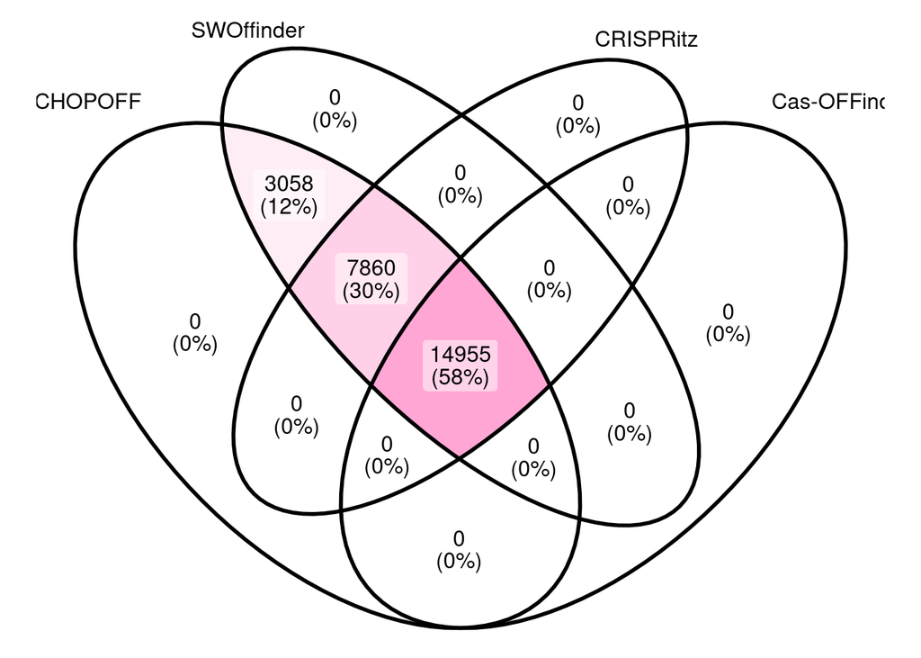